# Data transformations

## Introduction

Data visualization is an important part of data science, nevertheless to get to that point it is important to know how to transform row data in order to make the data a little easier to work with. Often you’ll need to create some new variables or summaries, or maybe you just want to rename the variables or reorder the observations.

## Dplyr basics

In this part of the course we will use dplyr package to manipulate the data, it proves a set of functions that help you solve the most common data manipulation challenges like:

- filter() picks cases based on their values.
- arrange() changes the ordering of the rows.
- select() picks variables based on their names.
- mutate() adds new variables that are functions of existing variables.
- summarise() reduces multiple values down to a single summary.

All verbs work similarly:

The first argument is a data frame. The subsequent arguments describe what to do with the data frame, using the variable names (without quotes). The result is a new data frame.

for this exercise we’ll use a new dataset on flights departing New York City in 2013 named nycflights13, so first we have to install the packages.

```r
install.packages("nycflights13")
```

[output not shown]

```r
library(nycflights13)
library(tidyverse)
```

Now we can display the data set:

```r
flights
```

| year | month | day | dep_time | sched_dep_time | dep_delay | arr_time | sched_arr_time | arr_delay | carrier | flight | tailnum | origin | dest | air_time | distance | hour | minute | time_hour |
| --- | --- | --- | --- | --- | --- | --- | --- | --- | --- | --- | --- | --- | --- | --- | --- | --- | --- | --- |
| 2013 | 1 | 1 | 517 | 515 | 2 | 830 | 819 | 11 | UA | 1545 | N14228 | EWR | IAH | 227 | 1400 | 5 | 15 | 2013-01-01 05:00:00 |
| 2013 | 1 | 1 | 533 | 529 | 4 | 850 | 830 | 20 | UA | 1714 | N24211 | LGA | IAH | 227 | 1416 | 5 | 29 | 2013-01-01 05:00:00 |
| 2013 | 1 | 1 | 542 | 540 | 2 | 923 | 850 | 33 | AA | 1141 | N619AA | JFK | MIA | 160 | 1089 | 5 | 40 | 2013-01-01 05:00:00 |
| 2013 | 1 | 1 | 544 | 545 | -1 | 1004 | 1022 | -18 | B6 | 725 | N804JB | JFK | BQN | 183 | 1576 | 5 | 45 | 2013-01-01 05:00:00 |
| 2013 | 1 | 1 | 554 | 600 | -6 | 812 | 837 | -25 | DL | 461 | N668DN | LGA | ATL | 116 | 762 | 6 | 0 | 2013-01-01 06:00:00 |
| 2013 | 1 | 1 | 554 | 558 | -4 | 740 | 728 | 12 | UA | 1696 | N39463 | EWR | ORD | 150 | 719 | 5 | 58 | 2013-01-01 05:00:00 |
| 2013 | 1 | 1 | 555 | 600 | -5 | 913 | 854 | 19 | B6 | 507 | N516JB | EWR | FLL | 158 | 1065 | 6 | 0 | 2013-01-01 06:00:00 |
| 2013 | 1 | 1 | 557 | 600 | -3 | 709 | 723 | -14 | EV | 5708 | N829AS | LGA | IAD | 53 | 229 | 6 | 0 | 2013-01-01 06:00:00 |
| 2013 | 1 | 1 | 557 | 600 | -3 | 838 | 846 | -8 | B6 | 79 | N593JB | JFK | MCO | 140 | 944 | 6 | 0 | 2013-01-01 06:00:00 |
| 2013 | 1 | 1 | 558 | 600 | -2 | 753 | 745 | 8 | AA | 301 | N3ALAA | LGA | ORD | 138 | 733 | 6 | 0 | 2013-01-01 06:00:00 |

[output cut: 990 more lines]

## Filter() picks cases based on their values

To filter the data the first argument is the name of the data frame, followed by the arguments that filter the data of instance, we are going to get the fights on January 1st with:

```r
filter(flights, month == 1, day == 1)
```

| year | month | day | dep_time | sched_dep_time | dep_delay | arr_time | sched_arr_time | arr_delay | carrier | flight | tailnum | origin | dest | air_time | distance | hour | minute | time_hour |
| --- | --- | --- | --- | --- | --- | --- | --- | --- | --- | --- | --- | --- | --- | --- | --- | --- | --- | --- |
| 2013 | 1 | 1 | 517 | 515 | 2 | 830 | 819 | 11 | UA | 1545 | N14228 | EWR | IAH | 227 | 1400 | 5 | 15 | 2013-01-01 05:00:00 |
| 2013 | 1 | 1 | 533 | 529 | 4 | 850 | 830 | 20 | UA | 1714 | N24211 | LGA | IAH | 227 | 1416 | 5 | 29 | 2013-01-01 05:00:00 |
| 2013 | 1 | 1 | 542 | 540 | 2 | 923 | 850 | 33 | AA | 1141 | N619AA | JFK | MIA | 160 | 1089 | 5 | 40 | 2013-01-01 05:00:00 |
| 2013 | 1 | 1 | 544 | 545 | -1 | 1004 | 1022 | -18 | B6 | 725 | N804JB | JFK | BQN | 183 | 1576 | 5 | 45 | 2013-01-01 05:00:00 |
| 2013 | 1 | 1 | 554 | 600 | -6 | 812 | 837 | -25 | DL | 461 | N668DN | LGA | ATL | 116 | 762 | 6 | 0 | 2013-01-01 06:00:00 |
| 2013 | 1 | 1 | 554 | 558 | -4 | 740 | 728 | 12 | UA | 1696 | N39463 | EWR | ORD | 150 | 719 | 5 | 58 | 2013-01-01 05:00:00 |
| 2013 | 1 | 1 | 555 | 600 | -5 | 913 | 854 | 19 | B6 | 507 | N516JB | EWR | FLL | 158 | 1065 | 6 | 0 | 2013-01-01 06:00:00 |
| 2013 | 1 | 1 | 557 | 600 | -3 | 709 | 723 | -14 | EV | 5708 | N829AS | LGA | IAD | 53 | 229 | 6 | 0 | 2013-01-01 06:00:00 |
| 2013 | 1 | 1 | 557 | 600 | -3 | 838 | 846 | -8 | B6 | 79 | N593JB | JFK | MCO | 140 | 944 | 6 | 0 | 2013-01-01 06:00:00 |
| 2013 | 1 | 1 | 558 | 600 | -2 | 753 | 745 | 8 | AA | 301 | N3ALAA | LGA | ORD | 138 | 733 | 6 | 0 | 2013-01-01 06:00:00 |

[output cut: 832 more lines]

When you run that line of code, dplyr executes the filtering operation and returns a new data frame. To save the result, you’ll need to use the assignment operator(<-):

```r
(jan1 <- filter(flights, month == 1, day == 1))
```

| year | month | day | dep_time | sched_dep_time | dep_delay | arr_time | sched_arr_time | arr_delay | carrier | flight | tailnum | origin | dest | air_time | distance | hour | minute | time_hour |
| --- | --- | --- | --- | --- | --- | --- | --- | --- | --- | --- | --- | --- | --- | --- | --- | --- | --- | --- |
| 2013 | 1 | 1 | 517 | 515 | 2 | 830 | 819 | 11 | UA | 1545 | N14228 | EWR | IAH | 227 | 1400 | 5 | 15 | 2013-01-01 05:00:00 |
| 2013 | 1 | 1 | 533 | 529 | 4 | 850 | 830 | 20 | UA | 1714 | N24211 | LGA | IAH | 227 | 1416 | 5 | 29 | 2013-01-01 05:00:00 |
| 2013 | 1 | 1 | 542 | 540 | 2 | 923 | 850 | 33 | AA | 1141 | N619AA | JFK | MIA | 160 | 1089 | 5 | 40 | 2013-01-01 05:00:00 |
| 2013 | 1 | 1 | 544 | 545 | -1 | 1004 | 1022 | -18 | B6 | 725 | N804JB | JFK | BQN | 183 | 1576 | 5 | 45 | 2013-01-01 05:00:00 |
| 2013 | 1 | 1 | 554 | 600 | -6 | 812 | 837 | -25 | DL | 461 | N668DN | LGA | ATL | 116 | 762 | 6 | 0 | 2013-01-01 06:00:00 |
| 2013 | 1 | 1 | 554 | 558 | -4 | 740 | 728 | 12 | UA | 1696 | N39463 | EWR | ORD | 150 | 719 | 5 | 58 | 2013-01-01 05:00:00 |
| 2013 | 1 | 1 | 555 | 600 | -5 | 913 | 854 | 19 | B6 | 507 | N516JB | EWR | FLL | 158 | 1065 | 6 | 0 | 2013-01-01 06:00:00 |
| 2013 | 1 | 1 | 557 | 600 | -3 | 709 | 723 | -14 | EV | 5708 | N829AS | LGA | IAD | 53 | 229 | 6 | 0 | 2013-01-01 06:00:00 |
| 2013 | 1 | 1 | 557 | 600 | -3 | 838 | 846 | -8 | B6 | 79 | N593JB | JFK | MCO | 140 | 944 | 6 | 0 | 2013-01-01 06:00:00 |
| 2013 | 1 | 1 | 558 | 600 | -2 | 753 | 745 | 8 | AA | 301 | N3ALAA | LGA | ORD | 138 | 733 | 6 | 0 | 2013-01-01 06:00:00 |

[output cut: 832 more lines]

To make a more accurate search you can use logical operators like: & (and), | (or), and ! (not).

```r
filter(flights, month == 11 | month == 12)
```

| year | month | day | dep_time | sched_dep_time | dep_delay | arr_time | sched_arr_time | arr_delay | carrier | flight | tailnum | origin | dest | air_time | distance | hour | minute | time_hour |
| --- | --- | --- | --- | --- | --- | --- | --- | --- | --- | --- | --- | --- | --- | --- | --- | --- | --- | --- |
| 2013 | 11 | 1 | 5 | 2359 | 6 | 352 | 345 | 7 | B6 | 745 | N568JB | JFK | PSE | 205 | 1617 | 23 | 59 | 2013-11-01 23:00:00 |
| 2013 | 11 | 1 | 35 | 2250 | 105 | 123 | 2356 | 87 | B6 | 1816 | N353JB | JFK | SYR | 36 | 209 | 22 | 50 | 2013-11-01 22:00:00 |
| 2013 | 11 | 1 | 455 | 500 | -5 | 641 | 651 | -10 | US | 1895 | N192UW | EWR | CLT | 88 | 529 | 5 | 0 | 2013-11-01 05:00:00 |
| 2013 | 11 | 1 | 539 | 545 | -6 | 856 | 827 | 29 | UA | 1714 | N38727 | LGA | IAH | 229 | 1416 | 5 | 45 | 2013-11-01 05:00:00 |
| 2013 | 11 | 1 | 542 | 545 | -3 | 831 | 855 | -24 | AA | 2243 | N5CLAA | JFK | MIA | 147 | 1089 | 5 | 45 | 2013-11-01 05:00:00 |
| 2013 | 11 | 1 | 549 | 600 | -11 | 912 | 923 | -11 | UA | 303 | N595UA | JFK | SFO | 359 | 2586 | 6 | 0 | 2013-11-01 06:00:00 |
| 2013 | 11 | 1 | 550 | 600 | -10 | 705 | 659 | 6 | US | 2167 | N748UW | LGA | DCA | 57 | 214 | 6 | 0 | 2013-11-01 06:00:00 |
| 2013 | 11 | 1 | 554 | 600 | -6 | 659 | 701 | -2 | US | 2134 | N742PS | LGA | BOS | 40 | 184 | 6 | 0 | 2013-11-01 06:00:00 |
| 2013 | 11 | 1 | 554 | 600 | -6 | 826 | 827 | -1 | DL | 563 | N912DE | LGA | ATL | 126 | 762 | 6 | 0 | 2013-11-01 06:00:00 |
| 2013 | 11 | 1 | 554 | 600 | -6 | 749 | 751 | -2 | DL | 731 | N315NB | LGA | DTW | 93 | 502 | 6 | 0 | 2013-11-01 06:00:00 |

[output cut: 990 more lines]

Another useful logical operator is %in%. This will select every row where x is one of the values in y. We could use it to rewrite the code above:

```r
(nov_dec <- filter(flights, month %in% c(11, 12)))
```

| year | month | day | dep_time | sched_dep_time | dep_delay | arr_time | sched_arr_time | arr_delay | carrier | flight | tailnum | origin | dest | air_time | distance | hour | minute | time_hour |
| --- | --- | --- | --- | --- | --- | --- | --- | --- | --- | --- | --- | --- | --- | --- | --- | --- | --- | --- |
| 2013 | 11 | 1 | 5 | 2359 | 6 | 352 | 345 | 7 | B6 | 745 | N568JB | JFK | PSE | 205 | 1617 | 23 | 59 | 2013-11-01 23:00:00 |
| 2013 | 11 | 1 | 35 | 2250 | 105 | 123 | 2356 | 87 | B6 | 1816 | N353JB | JFK | SYR | 36 | 209 | 22 | 50 | 2013-11-01 22:00:00 |
| 2013 | 11 | 1 | 455 | 500 | -5 | 641 | 651 | -10 | US | 1895 | N192UW | EWR | CLT | 88 | 529 | 5 | 0 | 2013-11-01 05:00:00 |
| 2013 | 11 | 1 | 539 | 545 | -6 | 856 | 827 | 29 | UA | 1714 | N38727 | LGA | IAH | 229 | 1416 | 5 | 45 | 2013-11-01 05:00:00 |
| 2013 | 11 | 1 | 542 | 545 | -3 | 831 | 855 | -24 | AA | 2243 | N5CLAA | JFK | MIA | 147 | 1089 | 5 | 45 | 2013-11-01 05:00:00 |
| 2013 | 11 | 1 | 549 | 600 | -11 | 912 | 923 | -11 | UA | 303 | N595UA | JFK | SFO | 359 | 2586 | 6 | 0 | 2013-11-01 06:00:00 |
| 2013 | 11 | 1 | 550 | 600 | -10 | 705 | 659 | 6 | US | 2167 | N748UW | LGA | DCA | 57 | 214 | 6 | 0 | 2013-11-01 06:00:00 |
| 2013 | 11 | 1 | 554 | 600 | -6 | 659 | 701 | -2 | US | 2134 | N742PS | LGA | BOS | 40 | 184 | 6 | 0 | 2013-11-01 06:00:00 |
| 2013 | 11 | 1 | 554 | 600 | -6 | 826 | 827 | -1 | DL | 563 | N912DE | LGA | ATL | 126 | 762 | 6 | 0 | 2013-11-01 06:00:00 |
| 2013 | 11 | 1 | 554 | 600 | -6 | 749 | 751 | -2 | DL | 731 | N315NB | LGA | DTW | 93 | 502 | 6 | 0 | 2013-11-01 06:00:00 |

[output cut: 990 more lines]

Another example of filtering:

```r
(filter(flights, arr_delay <= 120, dep_delay <= 120))
```

| year | month | day | dep_time | sched_dep_time | dep_delay | arr_time | sched_arr_time | arr_delay | carrier | flight | tailnum | origin | dest | air_time | distance | hour | minute | time_hour |
| --- | --- | --- | --- | --- | --- | --- | --- | --- | --- | --- | --- | --- | --- | --- | --- | --- | --- | --- |
| 2013 | 1 | 1 | 517 | 515 | 2 | 830 | 819 | 11 | UA | 1545 | N14228 | EWR | IAH | 227 | 1400 | 5 | 15 | 2013-01-01 05:00:00 |
| 2013 | 1 | 1 | 533 | 529 | 4 | 850 | 830 | 20 | UA | 1714 | N24211 | LGA | IAH | 227 | 1416 | 5 | 29 | 2013-01-01 05:00:00 |
| 2013 | 1 | 1 | 542 | 540 | 2 | 923 | 850 | 33 | AA | 1141 | N619AA | JFK | MIA | 160 | 1089 | 5 | 40 | 2013-01-01 05:00:00 |
| 2013 | 1 | 1 | 544 | 545 | -1 | 1004 | 1022 | -18 | B6 | 725 | N804JB | JFK | BQN | 183 | 1576 | 5 | 45 | 2013-01-01 05:00:00 |
| 2013 | 1 | 1 | 554 | 600 | -6 | 812 | 837 | -25 | DL | 461 | N668DN | LGA | ATL | 116 | 762 | 6 | 0 | 2013-01-01 06:00:00 |
| 2013 | 1 | 1 | 554 | 558 | -4 | 740 | 728 | 12 | UA | 1696 | N39463 | EWR | ORD | 150 | 719 | 5 | 58 | 2013-01-01 05:00:00 |
| 2013 | 1 | 1 | 555 | 600 | -5 | 913 | 854 | 19 | B6 | 507 | N516JB | EWR | FLL | 158 | 1065 | 6 | 0 | 2013-01-01 06:00:00 |
| 2013 | 1 | 1 | 557 | 600 | -3 | 709 | 723 | -14 | EV | 5708 | N829AS | LGA | IAD | 53 | 229 | 6 | 0 | 2013-01-01 06:00:00 |
| 2013 | 1 | 1 | 557 | 600 | -3 | 838 | 846 | -8 | B6 | 79 | N593JB | JFK | MCO | 140 | 944 | 6 | 0 | 2013-01-01 06:00:00 |
| 2013 | 1 | 1 | 558 | 600 | -2 | 753 | 745 | 8 | AA | 301 | N3ALAA | LGA | ORD | 138 | 733 | 6 | 0 | 2013-01-01 06:00:00 |

[output cut: 990 more lines]

## Filtering exercises

1.- Filter all the flights with a delay bigger than two hours at the arrivals

2.- Filter all the delayed flights in autumn

## Arrange() changes the ordering of the rows

arrange() takes a data frame and a set of column names and order them. If you provide more than one column name, each additional column will be used reorder ties in the values of preceding columns:

```r
(arrange(flights, desc(arr_delay)))
```

| year | month | day | dep_time | sched_dep_time | dep_delay | arr_time | sched_arr_time | arr_delay | carrier | flight | tailnum | origin | dest | air_time | distance | hour | minute | time_hour |
| --- | --- | --- | --- | --- | --- | --- | --- | --- | --- | --- | --- | --- | --- | --- | --- | --- | --- | --- |
| 2013 | 1 | 9 | 641 | 900 | 1301 | 1242 | 1530 | 1272 | HA | 51 | N384HA | JFK | HNL | 640 | 4983 | 9 | 0 | 2013-01-09 09:00:00 |
| 2013 | 6 | 15 | 1432 | 1935 | 1137 | 1607 | 2120 | 1127 | MQ | 3535 | N504MQ | JFK | CMH | 74 | 483 | 19 | 35 | 2013-06-15 19:00:00 |
| 2013 | 1 | 10 | 1121 | 1635 | 1126 | 1239 | 1810 | 1109 | MQ | 3695 | N517MQ | EWR | ORD | 111 | 719 | 16 | 35 | 2013-01-10 16:00:00 |
| 2013 | 9 | 20 | 1139 | 1845 | 1014 | 1457 | 2210 | 1007 | AA | 177 | N338AA | JFK | SFO | 354 | 2586 | 18 | 45 | 2013-09-20 18:00:00 |
| 2013 | 7 | 22 | 845 | 1600 | 1005 | 1044 | 1815 | 989 | MQ | 3075 | N665MQ | JFK | CVG | 96 | 589 | 16 | 0 | 2013-07-22 16:00:00 |
| 2013 | 4 | 10 | 1100 | 1900 | 960 | 1342 | 2211 | 931 | DL | 2391 | N959DL | JFK | TPA | 139 | 1005 | 19 | 0 | 2013-04-10 19:00:00 |
| 2013 | 3 | 17 | 2321 | 810 | 911 | 135 | 1020 | 915 | DL | 2119 | N927DA | LGA | MSP | 167 | 1020 | 8 | 10 | 2013-03-17 08:00:00 |
| 2013 | 7 | 22 | 2257 | 759 | 898 | 121 | 1026 | 895 | DL | 2047 | N6716C | LGA | ATL | 109 | 762 | 7 | 59 | 2013-07-22 07:00:00 |
| 2013 | 12 | 5 | 756 | 1700 | 896 | 1058 | 2020 | 878 | AA | 172 | N5DMAA | EWR | MIA | 149 | 1085 | 17 | 0 | 2013-12-05 17:00:00 |
| 2013 | 5 | 3 | 1133 | 2055 | 878 | 1250 | 2215 | 875 | MQ | 3744 | N523MQ | EWR | ORD | 112 | 719 | 20 | 55 | 2013-05-03 20:00:00 |

[output cut: 990 more lines]

## Select() picks variables based on their names

Select () is useful when you have datasets with hundreds or even thousands of variables, it allows you to pick them in order to make a subset using operations based on the names of the variables. Thereby, you can work with the variables of your interest. First you have to identify the dataset and then the name of the columns.

```r
# Select columns by name
(select(flights, year, month, day))
```

| year | month | day |
| --- | --- | --- |
| 2013 | 1 | 1 |
| 2013 | 1 | 1 |
| 2013 | 1 | 1 |
| 2013 | 1 | 1 |
| 2013 | 1 | 1 |
| 2013 | 1 | 1 |
| 2013 | 1 | 1 |
| 2013 | 1 | 1 |
| 2013 | 1 | 1 |
| 2013 | 1 | 1 |

[output cut: 990 more lines]

Also you can select the column between tow variables. With the next code you are selecting all the columns between year and sched_dep_time.

```r
# Select all columns between year and day (inclusive)
select(flights, year:sched_dep_time)
```

| year | month | day | dep_time | sched_dep_time |
| --- | --- | --- | --- | --- |
| 2013 | 1 | 1 | 517 | 515 |
| 2013 | 1 | 1 | 533 | 529 |
| 2013 | 1 | 1 | 542 | 540 |
| 2013 | 1 | 1 | 544 | 545 |
| 2013 | 1 | 1 | 554 | 600 |
| 2013 | 1 | 1 | 554 | 558 |
| 2013 | 1 | 1 | 555 | 600 |
| 2013 | 1 | 1 | 557 | 600 |
| 2013 | 1 | 1 | 557 | 600 |
| 2013 | 1 | 1 | 558 | 600 |

[output cut: 990 more lines]

## Mutate() adds new variables that are functions of existing variables

Mutate () adds new columns at the end of the dataset that are functions of the existing ones. We will create a narrower dataset called flights_sml that contains less columns than the original and add two new columns: gain and speed.

```r
flights_sml <- select(flights,
  year:day,
  ends_with("delay"),
  distance,
  air_time
)
mutate(flights_sml,
  gain = arr_delay - dep_delay,
  speed = distance / air_time * 60
)
```

| year | month | day | dep_delay | arr_delay | distance | air_time | gain | speed |
| --- | --- | --- | --- | --- | --- | --- | --- | --- |
| 2013 | 1 | 1 | 2 | 11 | 1400 | 227 | 9 | 370.0441 |
| 2013 | 1 | 1 | 4 | 20 | 1416 | 227 | 16 | 374.2731 |
| 2013 | 1 | 1 | 2 | 33 | 1089 | 160 | 31 | 408.3750 |
| 2013 | 1 | 1 | -1 | -18 | 1576 | 183 | -17 | 516.7213 |
| 2013 | 1 | 1 | -6 | -25 | 762 | 116 | -19 | 394.1379 |
| 2013 | 1 | 1 | -4 | 12 | 719 | 150 | 16 | 287.6000 |
| 2013 | 1 | 1 | -5 | 19 | 1065 | 158 | 24 | 404.4304 |
| 2013 | 1 | 1 | -3 | -14 | 229 | 53 | -11 | 259.2453 |
| 2013 | 1 | 1 | -3 | -8 | 944 | 140 | -5 | 404.5714 |
| 2013 | 1 | 1 | -2 | 8 | 733 | 138 | 10 | 318.6957 |

[output cut: 990 more lines]

You can add another columns by using the ones that you are mutating.

```r
mutate(flights_sml,
  gain = arr_delay - dep_delay,
  hours = air_time / 60,
  gain_per_hour = gain / hours
)
```

| year | month | day | dep_delay | arr_delay | distance | air_time | gain | hours | gain_per_hour |
| --- | --- | --- | --- | --- | --- | --- | --- | --- | --- |
| 2013 | 1 | 1 | 2 | 11 | 1400 | 227 | 9 | 3.7833333 | 2.3788546 |
| 2013 | 1 | 1 | 4 | 20 | 1416 | 227 | 16 | 3.7833333 | 4.2290749 |
| 2013 | 1 | 1 | 2 | 33 | 1089 | 160 | 31 | 2.6666667 | 11.6250000 |
| 2013 | 1 | 1 | -1 | -18 | 1576 | 183 | -17 | 3.0500000 | -5.5737705 |
| 2013 | 1 | 1 | -6 | -25 | 762 | 116 | -19 | 1.9333333 | -9.8275862 |
| 2013 | 1 | 1 | -4 | 12 | 719 | 150 | 16 | 2.5000000 | 6.4000000 |
| 2013 | 1 | 1 | -5 | 19 | 1065 | 158 | 24 | 2.6333333 | 9.1139241 |
| 2013 | 1 | 1 | -3 | -14 | 229 | 53 | -11 | 0.8833333 | -12.4528302 |
| 2013 | 1 | 1 | -3 | -8 | 944 | 140 | -5 | 2.3333333 | -2.1428571 |
| 2013 | 1 | 1 | -2 | 8 | 733 | 138 | 10 | 2.3000000 | 4.3478261 |

[output cut: 990 more lines]

## Summarise() reduces multiple values down to a single summary

The next code will create the variable delay by summarizing the mean of dep_delay without counting the null values

```r
summarise(flights, delay = mean(dep_delay, na.rm = TRUE)) #na.rm doesn't count null values
```

| delay |
| --- |
| 12.63907 |

the summarize function is better to use together with group_by(), because it provides grouped summaries.

```r
by_day <- group_by(flights, year, month, day)
summarise(by_day, delay = mean(dep_delay, na.rm = TRUE))
```

| year | month | day | delay |
| --- | --- | --- | --- |
| 2013 | 1 | 1 | 11.54892601 |
| 2013 | 1 | 2 | 13.85882353 |
| 2013 | 1 | 3 | 10.98783186 |
| 2013 | 1 | 4 | 8.95159516 |
| 2013 | 1 | 5 | 5.73221757 |
| 2013 | 1 | 6 | 7.14801444 |
| 2013 | 1 | 7 | 5.41720430 |
| 2013 | 1 | 8 | 2.55307263 |
| 2013 | 1 | 9 | 2.27647715 |
| 2013 | 1 | 10 | 2.84499462 |

[output cut: 355 more lines]

Now we will create two new variables: by month (flights grouped by months) and d_bymonth (the summary of the mean delay by month), note that the first one is used as variable in the second function.

```r
by_month <- group_by(flights, month)
(d_bymonth <- summarise(by_month, delay = mean(dep_delay, na.rm = TRUE)))
```

| month | delay |
| --- | --- |
| 1 | 10.036665 |
| 2 | 10.816843 |
| 3 | 13.227076 |
| 4 | 13.938038 |
| 5 | 12.986859 |
| 6 | 20.846332 |
| 7 | 21.727787 |
| 8 | 12.611040 |
| 9 | 6.722476 |
| 10 | 6.243988 |

[output cut: 2 more lines]

Once we transform the data now we are going to visualize them

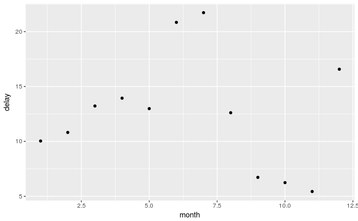

```r
ggplot(data = d_bymonth) +
  geom_point(mapping = aes (x = month, y= delay))
```

## Combining multiple operators

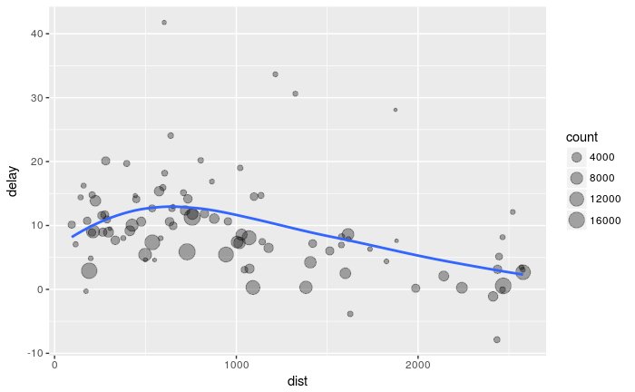

```r
by_dest <- group_by(flights, dest)
delay <- summarise(by_dest,
  count = n(),
  dist = mean(distance, na.rm = TRUE),
  delay = mean(arr_delay, na.rm = TRUE)
)
delay <- filter(delay, count > 20, dest != "HNL")
# It looks like delays increase with distance up to ~750 miles
# and then decrease. Maybe as flights get longer there's more
# ability to make up delays in the air?
ggplot(data = delay, mapping = aes(x = dist, y = delay)) +
  geom_point(aes(size = count), alpha = 1/3) +
  geom_smooth(se = FALSE)
```

## The use of pipes

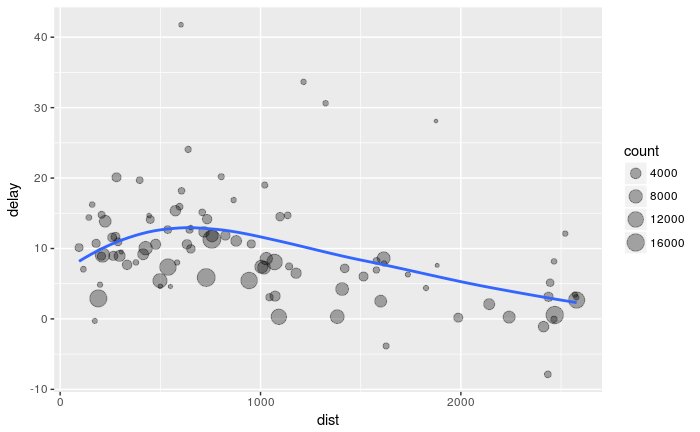

```r
delay <- group_by(flights, dest) %>%
  summarise(
    count = n(),
    dist = mean(distance, na.rm = TRUE),
    delay = mean(arr_delay, na.rm = TRUE)
  ) %>%
filter(count > 20, dest != "HNL")
# It looks like delays increase with distance up to ~750 miles
# and then decrease. Maybe as flights get longer there's more
# ability to make up delays in the air?
ggplot(data = delay, mapping = aes(x = dist, y = delay)) +
  geom_point(aes(size = count), alpha = 1/3) +
  geom_smooth(se = FALSE)
```